# Class 20

DATA1220-55, Fall 2024

Sarah E. Grabinski

2024-10-18

## Hypothesis Testing Framework

- $\mathbf{H_0}$: The “Null” Hypothesis
  - Represents a position of skepticism, *nothing* is happening here
  - “There is *not* an association between process A and B”
- $\mathbf{H_A}$: The “Alternative” Hypothesis
  - The complement of $H_0$, *something* is happening here
  - “There *is* an association between process A and B”

## Conducting a hypothesis test

- Begin by *assuming* $H_0$ is the “true” state
- Calculate *the probability that you would see results as extreme or more extreme* than what you saw in your study, assuming the distribution under $H_0$
- The lower the probability, the less likely it is that we would see these results if $H_0$ was the “true” state of our population
- If the probability is sufficiently low, we *reject* $\mathbf{H_0}$ and *accept* $\mathbf{H_A}$

## Example: One Proportion

In a 2024 Ipsos survey of a representative sample of 2,027 Americans, 1,155 respondents (57.0%) reported that they had a favorable opinion of Tom Hanks, down from 75% in 2018.

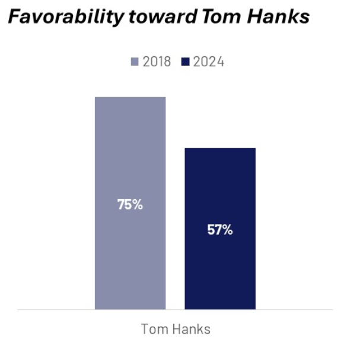

## Hypotheses

- $H_0$: Americans do not have an opinion on Tom Hanks.

$$P(\operatorname{Favorable}) = 0.5$$

- $H_A$: Americans do have an opinion on Tom Hanks.

$$P(\operatorname{Favorable}) \ne 0.5$$

## 95% Confidence Interval

1. Calculate the standard error of the measurement for a proportion.

$$SE=\sqrt{\frac{\hat{p}(1-\hat{p})}{n}}$$

2. Find $Z^*$ for $\alpha = 0.05$.

$$Z^*=Z_{1-\alpha/2}$$

3. Construct confidence interval as $\operatorname{point estimate} \pm Z^* \times SE$

## Standard Error

$$\begin{aligned}
SE&=\sqrt{\frac{\hat{p}(1-\hat{p})}{n}} \\
&= \sqrt{\frac{0.57(1-0.57)}{2027}} \\
&=0.011
\end{aligned}$$

```r
sqrt((0.57 * (1 - 0.57)) / 2027)
```

```
[1] 0.01099625
```

## Finding $Z^*$

$$\begin{aligned}
Z^*&=Z_{1-\alpha/2} \\
&=Z_{1-0.025} \\
&=Z_{0.975}
\end{aligned}$$

```r
qnorm(0.975)
```

```
[1] 1.959964
```

## Calculating the Margin of Error

$$\begin{aligned}
\operatorname{margin of error} &= Z^* \times SE \\
&= 1.96 \times 0.011 \\
&= 0.022
\end{aligned}$$

```r
qnorm(0.975) * sqrt((0.57 * (1 - 0.57)) / 2027)
```

```
[1] 0.02155226
```

## Finding the boundaries

```r
(1155 / 2027) - qnorm(0.975) * sqrt((0.57 * (1 - 0.57)) / 2027)
```

```
[1] 0.5482553
```

```r
(1155 / 2027) + qnorm(0.975) * sqrt((0.57 * (1 - 0.57)) / 2027)
```

```
[1] 0.5913599
```

## Interpreting the Confidence Interval

- With 95% confidence, 54.8% to 59.1% of Americans have a favorable opinion of Tom Hanks.
- 57.0% of Americans have a favorable opinion of Tom Hanks (95% CI: 54.8-59.1%).
- With 95% confidence, 57.0% $\pm$ 2.2% have a favorable opinion of Tom Hanks.

## Testing the Hypothesis

1. Find the sampling distribution $N(p, SE)$ under the null hypothesis.
2. Calculate the test statistic for the null hypothesis.

$$Z=\frac{\hat{p}-p}{SE}$$

3. Find the probability of getting a test statistic as extreme or more extreme as this one, assuming the null hypothesis is true.
4. If the p-value is less than $\alpha$, reject $H_0$ and accept $H_A$.

## Finding the Null Distribution

To find the null distribution, replace the sample statistic $\hat{p}=0.57$ with the population parameter $p=0.5$.

$$\begin{aligned}
SE&=\sqrt{\frac{p(1-p)}{n}} \\
&= \sqrt{\frac{0.5(1-0.5)}{2027}} \\
&=0.011
\end{aligned}$$

The null hypothesis is that our observed sample statistic $\hat{p}=0.57$ comes from the sampling distribution $N(\mu=0.5, \sigma=0.011)$.

## Calculating the test statistic

If the sampling distribution under $H_0$ is $\hat{p}\sim N(0.5, 0.011)$, then the test statistic for $\hat{p}=0.57$ is…

$$\begin{aligned}
Z &= \frac{\hat{p} - p}{SE} \\
&= \frac{0.57-0.5}{0.011} \\
&=6.36
\end{aligned}$$

$\hat{p}$ is 6.36 standard errors greater than $p$ under the null hypothesis.

## Get the p-value

- Use the test statistic $Z$ to find the two-sided probability $P(Z \ge 6.36 \operatorname{or} Z \le -6.36)$.

```r
pnorm(-6.36) + pnorm(6.36, lower.tail = F)
```

```
[1] 2.017537e-10
```

- If $H_0$:$P(\operatorname{Favorable}) = 0.5$ were true, then the probability that we would see a sample proportion as different from $p=0.5$ as $\hat{p}=0.57$ is very low.
- $P(\lvert Z \rvert \ge 6.36) < 0.05$, so we *reject* $H_0$ and *accept* $H_A$.

## Difference Between 2 Proportions

- In 2018, Ipsos surveyed 1,005 Americans using the same questions, and 754 (75.0%) had a favorable opinion of Tom Hanks.
- Research Question: Has Tom Hanks’ favorability dropped between 2018 and 2024?
- Does $\hat{p}_{2018}=\hat{p}_{2024}$? Does $\hat{p}_{2018}-\hat{p}_{2024}=0$?

## Sampling Distribution

- Sample statistic is the difference between 2 sample proportions $\hat{p}_1 - \hat{p}_2$
- When assumptions met, $\hat{p}_1-\hat{p}_2 \sim N(p_1-p_2, SE_{p_1-p_2})$

## Standard Error

The standard error for the difference between 2 proportions requires the population proportion $p$ and sample size $n$ for each group.

$$SE_{(\hat{p}_1-\hat{p}_2)}=\sqrt{\frac{p_1(1-p_1)}{n_1}+\frac{p_2(1-p_2)}{n_2}}$$

## Assumptions

- Observations within each sample are independent of each other.
- There are 10+ successes and 10+ failures in each sample.
- Sample 1 is independent of Sample 2.

## Hypotheses

- $H_0$: The proportion of Americans who view Tom Hanks favorably did not change between 2018 and 2024.

$$P(\operatorname{Favorable in 2018}) = P(\operatorname{Favorable in 2024})$$

- $H_A$: The proportion of Americans who view Tom Hanks favorably changed between 2018 and 2024.

$$P(\operatorname{Favorable in 2018}) \ne P(\operatorname{Favorable in 2024})$$

## Hypotheses

- $H_0$: The proportion of Americans who view Tom Hanks favorably did not change between 2018 and 2024.

$$P(\operatorname{Favorable in 2018}) - P(\operatorname{Favorable in 2024})=0$$

- $H_A$: The proportion of Americans who view Tom Hanks favorably changed between 2018 and 2024.

$$P(\operatorname{Favorable in 2018}) - P(\operatorname{Favorable in 2024}) \ne 0$$

## 95% Confidence Interval

1. Find the point estimate for the difference in proportions $\hat{p}_1-\hat{p}_2$.
2. Calculate the standard error for the difference between 2 proportions.

$$SE_{(\hat{p}_1-\hat{p}_2)}=\sqrt{\frac{p_1(1-p_1)}{n_1}+\frac{p_2(1-p_2)}{n_2}}$$

2. Find $Z^*$ for $\alpha = 0.05$.

$$Z^*=Z_{1-\alpha/2}$$

3. Construct confidence interval as $\hat{p}_1 - \hat{p}_2 \pm Z^* \times SE$

## Point Estimate

$$\begin{aligned}
\hat{p}_1-\hat{p}_2&=\frac{754}{1005}-\frac{1155}{2027} \\
&= 0.180
\end{aligned}$$

## Standard Error

When constructing a confidence interval for $\hat{p}_1-\hat{p}_2$, we use the sample proportions $\hat{p}_1$ and $\hat{p}_2$ as estimates for the population parameters $p_1$ and $p_2$.

$$\begin{aligned}
SE_{(\hat{p}_1-\hat{p}_2)}&=\sqrt{\frac{p_1(1-p_1)}{n_1}+\frac{p_2(1-p_2)}{n_2}} \\
&=\sqrt{\frac{0.75(1-0.75)}{1005}+\frac{0.57(1-0.57)}{2027}} \\
&=0.018
\end{aligned}$$

## Finding $Z^*$

$$\begin{aligned}
Z^*&=Z_{1-\alpha/2} \\
&=Z_{1-0.025} \\
&=Z_{0.975}
\end{aligned}$$

```r
qnorm(0.975)
```

```
[1] 1.959964
```

## Calculating the Margin of Error

$$\begin{aligned}
\operatorname{margin of error} &= Z^* \times SE \\
&= 1.96 \times 0.018 \\
&= 0.034
\end{aligned}$$

```r
qnorm(0.975) * sqrt((0.75*(1-0.75))/1005 + (0.57*(1-0.57))/2027)
```

```
[1] 0.03436845
```

## Finding the boundaries

```r
diff <- ((754 / 1005) - (1155 / 2027))

margin <- qnorm(0.975) * sqrt((0.75*(1-0.75))/1005 + (0.57*(1-0.57))/2027)

diff - margin
```

```
[1] 0.1460727
```

```r
diff + margin
```

```
[1] 0.2148096
```

## Interpreting the Confidence Interval

- With 95% confidence, 14.6% to 21.5% more Americans had a favorable opinion of Tom Hanks in 2018 than in 2024.
- 18.0% more Americans had a favorable opinion of Tom Hanks in 2018 than in 2024 (95% CI: 14.6-21.5%).
- With 95% confidence, 18.0% $\pm$ 3.4% more Americans had a favorable opinion of Tom Hanks in 2018 than 2024.

## Testing the Hypothesis

1. Find the sampling distribution $N(0, SE_{p_1-p_2})$ under the null hypothesis.
2. Calculate the test statistic for the null hypothesis $p_1=p_2$.

$$Z=\frac{\hat{p}_1-\hat{p}_2}{SE_{p_1=p_2}}$$

3. Find the probability of getting a test statistic as extreme or more extreme as this one, assuming the null hypothesis is true.
4. If the p-value is less than $\alpha$, reject $H_0$ and accept $H_A$.

## Pooled Population Proportion

When the null hypothesis is that $p_1=p_2$ or $p_1-p_2=0$, we use the pooled population parameter $\hat{p}$ to calculate the standard error.

$$\begin{aligned}
\hat{p}_{\operatorname{pooled}}&=\frac{\operatorname{count}_1 + \operatorname{count}_2}{n_1+n_2} \\
&=\frac{754 + 1155}{1005 + 2027} \\
&=0.630
\end{aligned}$$

When $H_0$: $p_1-p_2 \ne 0$, then you use $\hat{p}_1$ and $\hat{p}_2$ when calculating the standard error for the hypothesis test.

## Finding the Null Distribution

To find the null distribution for $p_1=p_2$, replace the sample statistics $\hat{p}_1$ and $\hat{p}_2$ with the pooled population proportion $\hat{p}$.

$$\begin{aligned}
SE_{(p_1=p_2)}&=\sqrt{\frac{\hat{p}(1-\hat{p})}{n_1}+\frac{\hat{p}(1-\hat{p})}{n_2}} \\
&=\sqrt{\frac{0.630(1-0.630)}{1005}+\frac{0.630(1-0.630)}{2027}} \\
&=0.019
\end{aligned}$$

The null hypothesis is that our observed sample statistic $\hat{p}_1-\hat{p}_2$ comes from the sampling distribution $N(\mu=0, \sigma=0.019)$.

## Calculating the test statistic

If the sampling distribution under $H_0$ is $\hat{p}_1-\hat{p}_2 \sim N(0, 0.019)$, then the test statistic for $\hat{p}_1-\hat{p}_2=$ is…

$$\begin{aligned}
Z &= \frac{\hat{p} - p}{SE} \\
&= \frac{0.750-0.570}{0.019} \\
&=9.47
\end{aligned}$$

$\hat{p}_1-\hat{p}_2$ is 9.47 standard errors greater than $\hat{p}_1-\hat{p}_2=0$ under the null hypothesis.

## Get the p-value

- Use the test statistic $Z$ to find the two-sided probability $P(Z \ge 9.47 \operatorname{or} Z \le -9.47)$.

```r
pnorm(-9.47) + pnorm(9.47, lower.tail = F)
```

```
[1] 2.798437e-21
```

- If $H_0$:$p_{2018}=p_{2024}$ were true, then the probability that we would see a difference as large as 18.0% is very small.
- $P(\lvert Z \rvert \ge 9.47) < 0.05$, so we *reject* $H_0$ and *accept* $H_A$.

DATA1220-55 Fall 2024, Class 20 | Updated: 2024-10-18 | [Canvas](https://canvas.jcu.edu/courses/36290) | [Campuswire](https://campuswire.com/c/G6427C531/feed)